# Model tuning prediction

```python
import pandas as pd
import numpy as np
from datetime import datetime
pd.set_option('display.max_columns', None)

import warnings
warnings.simplefilter(action='ignore', category=FutureWarning)
```

```python
from numpy import mean
from numpy import std
from sklearn.datasets import make_regression
from sklearn.model_selection import cross_val_score
from sklearn.model_selection import RepeatedKFold
from sklearn.linear_model import LinearRegression
from sklearn.neighbors import KNeighborsRegressor
from sklearn.tree import DecisionTreeRegressor
from sklearn.svm import SVR
from sklearn.ensemble import StackingRegressor
from matplotlib import pyplot
from sklearn.linear_model import Ridge
from sklearn.model_selection import GridSearchCV
from sklearn.linear_model import Lasso
from sklearn.linear_model import LinearRegression
from sklearn.ensemble import RandomForestRegressor
from sklearn.ensemble import GradientBoostingRegressor
from yellowbrick.regressor import ResidualsPlot
from yellowbrick.regressor import PredictionError
from yellowbrick.regressor import CooksDistance
```

```python
df_train = pd.read_csv("dataset/train_set.csv")
df_valid = pd.read_csv("dataset/val_set.csv")
df_test  = pd.read_csv("dataset/test_set.csv")
```

### Clean n transform data

```python
df_train.shape
```

```
(7286, 85)
```

```python
df_valid.shape
```

```
(1877, 85)
```

```python
7286/1877
```

```
3.881726158763985
```

```python
df_test.shape
```

```
(2346, 85)
```

```python
df_train.dtypes[df_train.dtypes == "object"]
```

```
CountryCode    object
record_date    object
icon           object
dtype: object
```

```python
df_train.drop(['CountryCode','record_date'], axis=1, inplace=True)
df_valid.drop(['CountryCode','record_date'], axis=1, inplace=True)
df_test.drop(['CountryCode','record_date'], axis=1, inplace=True)
```

```python
icon_onehot_col = pd.get_dummies(df_train.icon)
df_train = pd.concat([df_train, icon_onehot_col], axis=1).drop(["icon"],axis=1)
icon_onehot_col = pd.get_dummies(df_valid.icon)
df_valid = pd.concat([df_valid, icon_onehot_col], axis=1).drop(["icon"],axis=1)
icon_onehot_col = pd.get_dummies(df_test.icon)
df_test = pd.concat([df_test, icon_onehot_col], axis=1).drop(["icon"],axis=1)
```

```python
df_train.head(2)
```

|  | Days since first case | c1_0_action | c1_1_action | c1_2_action | c1_3_action | c2_0_action | c2_1_action | c2_2_action | c2_3_action | c3_0_action | c3_1_action | c3_2_action | c4_0_action | c4_1_action | c4_2_action | c4_3_action | c4_4_action | c5_0_action | c5_1_action | c5_2_action | c6_0_action | c6_1_action | c6_2_action | c6_3_action | c7_0_action | c7_1_action | c7_2_action | c8_0_action | c8_1_action | … |
| --- | --- | --- | --- | --- | --- | --- | --- | --- | --- | --- | --- | --- | --- | --- | --- | --- | --- | --- | --- | --- | --- | --- | --- | --- | --- | --- | --- | --- | --- | --- |
| 0 | 1 | 2 | 0 | 0 | 0 | 2 | 0 | 0 | 0 | 2 | 0 | 0 | 2 | 0 | 0 | 0 | 0 | 2 | 0 | 0 | 2 | 0 | 0 | 0 | 2 | 0 | 0 | 0 | 0 | … |
| 1 | 2 | 0 | 0 | 0 | 1 | 3 | 0 | 0 | 0 | 3 | 0 | 0 | 0 | 0 | 1 | 0 | 0 | 3 | 0 | 0 | 3 | 0 | 0 | 0 | 3 | 0 | 0 | 0 | 0 | … |

### Feature Selection

#### Wrapper Method - Recursive Feature Elimination

```python
X_valid = df_valid.drop('Log_new_cases_per_million', axis=1)
from sklearn.preprocessing import StandardScaler
# X_valid = StandardScaler().fit_transform(X_valid)
y_valid = df_valid['Log_new_cases_per_million']

X_train = df_train.drop('Log_new_cases_per_million', axis=1)
# X_train = StandardScaler().fit_transform(X_train)
y_train = df_train['Log_new_cases_per_million']
```

```python
feature_names = X_valid.columns
```

```python
from sklearn.feature_selection import RFECV
from sklearn.linear_model import LinearRegression
estimator = LinearRegression(n_jobs=-1)
selector = RFECV(estimator,
                 step=1, #number of features to remove at each iteration
                 min_features_to_select=20, #The minimum number of features to be selected
                 cv=5)
selector = selector.fit(X_train, y_train)
new_features1 = []
for i,j in zip(selector.support_, feature_names):
    if i == True:
        new_features1.append(j)
df_train[new_features1].head(2)
```

|  | Days since first case | c1_0_action | c8_1_action | Outputvalue_lag1 | diabetes_prevalence | female_smokers | life_expectancy | cloudCover | dewPoint | humidity | precipIntensity | temperature | Sentiments | isHoliday | clear-day | clear-night | cloudy | partly-cloudy-day | partly-cloudy-night | wind |
| --- | --- | --- | --- | --- | --- | --- | --- | --- | --- | --- | --- | --- | --- | --- | --- | --- | --- | --- | --- | --- |
| 0 | 1 | 2 | 0 | 0.00000 | 3.94 | 2.586111 | 61.15 | 0.39 | 72.27 | 0.86 | 0.0030 | 76.71 | 0.0 | 1 | 0 | 0 | 0 | 0 | 1 | 0 |
| 1 | 2 | 0 | 0 | -1.21467 | 3.94 | 2.586111 | 61.15 | 0.68 | 72.75 | 0.92 | 0.0231 | 75.37 | 0.0 | -1 | 0 | 0 | 0 | 0 | 1 | 0 |

#### Filter Method - SelectKBest - Pearson’s Correlation Coefficient: f_regression()

```python
from sklearn.feature_selection import SelectKBest, f_regression
estimator = SelectKBest(f_regression, k=20) # Number of top features to select
selector = estimator.fit(X_train, y_train)
new_features4 = []
for i,j in zip(selector.get_support(), feature_names):
    if i == True:
        new_features4.append(j)
df_train[new_features4].head(2)
```

|  | Days since first case | c1_2_action | c2_0_action | c2_3_action | c3_2_action | c5_1_action | e1_0_action | e1_2_action | e2_2_action | h1_2_action | Outputvalue_lag1 | gdp_per_capita | cvd_death_rate | handwashing_facilities | hospital_beds_per_thousand | female_smokers | life_expectancy | aged_65_older_sum | urbanPopulation | healthExpenditure |
| --- | --- | --- | --- | --- | --- | --- | --- | --- | --- | --- | --- | --- | --- | --- | --- | --- | --- | --- | --- | --- |
| 0 | 1 | 0 | 2 | 0 | 0 | 0 | 2 | 0 | 0 | 0 | 0.00000 | 5819.495 | 276.045 | 26.664 | 2.1 | 2.586111 | 61.15 | 1.8835 | 66.177 | 1.291869 |
| 1 | 2 | 0 | 3 | 0 | 0 | 0 | 3 | 0 | 0 | 0 | -1.21467 | 5819.495 | 276.045 | 26.664 | 2.1 | 2.586111 | 61.15 | 1.8835 | 66.177 | 1.291869 |

```python
new_features1
```

```
['Days since first case',
 'c1_0_action',
 'c8_1_action',
 'Outputvalue_lag1',
 'diabetes_prevalence',
 'female_smokers',
 'life_expectancy',
 'cloudCover',
 'dewPoint',
 'humidity',
 'precipIntensity',
 'temperature',
 'Sentiments',
 'isHoliday',
 'clear-day',
 'clear-night',
 'cloudy',
 'partly-cloudy-day',
 'partly-cloudy-night',
 'wind']
```

```python
new_features1.append("Log_new_cases_per_million")
```

```python
df_train = pd.read_csv("dataset/train_set.csv")
df_valid = pd.read_csv("dataset/val_set.csv")
df_test  = pd.read_csv("dataset/test_set.csv")

df_train.drop(['CountryCode','record_date'], axis=1, inplace=True)
df_valid.drop(['CountryCode','record_date'], axis=1, inplace=True)
df_test.drop(['CountryCode','record_date'], axis=1, inplace=True)

icon_onehot_col = pd.get_dummies(df_train.icon)
df_train = pd.concat([df_train, icon_onehot_col], axis=1).drop(["icon"],axis=1)
icon_onehot_col = pd.get_dummies(df_valid.icon)
df_valid = pd.concat([df_valid, icon_onehot_col], axis=1).drop(["icon"],axis=1)
icon_onehot_col = pd.get_dummies(df_test.icon)
df_test = pd.concat([df_test, icon_onehot_col], axis=1).drop(["icon"],axis=1)

df_train = df_train[new_features1]
df_valid = df_valid[new_features1]
df_test = df_test[new_features1]
```

```python
from sklearn.preprocessing import StandardScaler
# X_valid = StandardScaler().fit_transform(X_valid)
y_valid = df_valid['Log_new_cases_per_million']
X_valid = df_valid.drop('Log_new_cases_per_million', axis=1)

y_train = df_train['Log_new_cases_per_million']
X_train = df_train.drop('Log_new_cases_per_million', axis=1)
# X_train = StandardScaler().fit_transform(X_train)
```

### Tunning Models

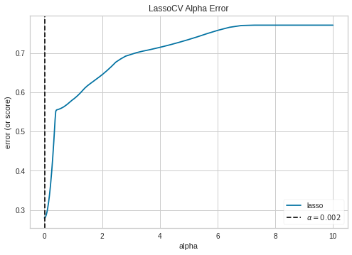

```python
from sklearn.linear_model import RidgeCV,LassoCV
from yellowbrick.regressor import AlphaSelection
from yellowbrick.regressor.alphas import alphas

alphas = np.logspace(-10, 1, 400)

model = LassoCV(alphas=alphas)
visualizer = AlphaSelection(model)
visualizer.fit(X_train, y_train)
visualizer.show()
```

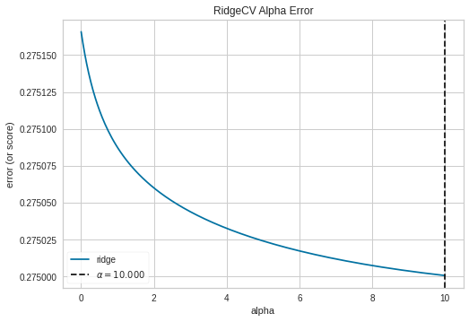

```python
alphas = np.logspace(-10, 1, 400)

model = RidgeCV(alphas=alphas, store_cv_values=True)
visualizer = AlphaSelection(model)
visualizer.fit(X_train, y_train)
visualizer.show()
```

### Train Model

```
>cart 0.467 (0.051)
>ranFor 0.631 (0.022)
>graBoost 0.708 (0.023)
>ridge 0.635 (0.022)
>linear_reg 0.635 (0.022)
>stacking 0.701 (0.022)
```

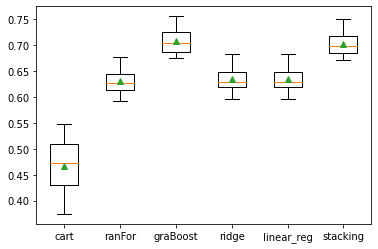

```python
def get_stacking():
    # define the base models
    level0 = list()
    level0.append(('cart', DecisionTreeRegressor()))
    level0.append(('ranFor',RandomForestRegressor(max_depth=2, random_state=0)))
    level0.append(('graBoost',GradientBoostingRegressor(random_state=0)))
    level0.append(('ridge', Ridge(alpha = 20,tol=0.001)))
    level0.append(('linear_reg', LinearRegression()))
    # define meta learner model
    level1 = LinearRegression()
    # define the stacking ensemble
    model = StackingRegressor(estimators=level0, final_estimator=level1, cv=5)
    return model

# get a list of models to evaluate
def get_models():
    models = dict()
    models['cart'] = DecisionTreeRegressor()
    models['ranFor'] = RandomForestRegressor(max_depth=2, random_state=0)
    models['graBoost'] = GradientBoostingRegressor(random_state=0)
    models['ridge'] = Ridge(alpha = 0.001)
    models['linear_reg'] = LinearRegression()
    models['stacking'] = get_stacking()
    return models

# evaluate a given model using cross-validation
def evaluate_model(model):
    cv = RepeatedKFold(n_splits=10, n_repeats=3, random_state=1)
    scores = cross_val_score(model, X_train, y_train, scoring='r2', cv=cv, n_jobs=-1, error_score='raise')
    return scores

# get the models to evaluate
models = get_models()

# evaluate the models and store results
results, names = list(), list()
for name, model in models.items():
    scores = evaluate_model(model)
    results.append(scores)
    names.append(name)
    print('>%s %.3f (%.3f)' % (name, mean(scores), std(scores)))

# plot model performance for comparison
pyplot.boxplot(results, labels=names, showmeans=True)
pyplot.show()
%matplotlib inline
```

### Feature Importance

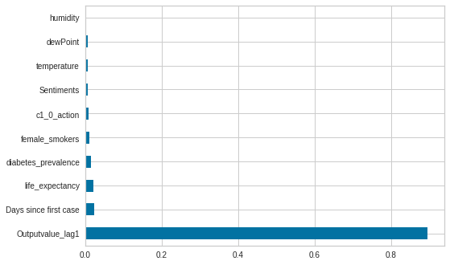

```python
reg = GradientBoostingRegressor(random_state=0)
reg.fit(X_train, y_train)
(pd.Series(reg.feature_importances_, index=X_train.columns)
   .nlargest(10)
   .plot(kind='barh'))
```

### Residuals + R2 plot

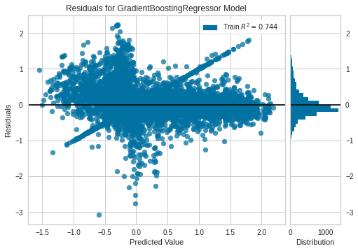

```python
model = GradientBoostingRegressor(random_state=0)
visualizer = ResidualsPlot(model)
visualizer.fit(X_train, y_train)
visualizer.show()
```

### Prediction Error Plot

A prediction error plot shows the actual targets from the dataset against the predicted values generated by our model. This allows us to see how much variance is in the model. Data scientists can diagnose regression models using this plot by comparing against the 45 degree line, where the prediction exactly matches the model.

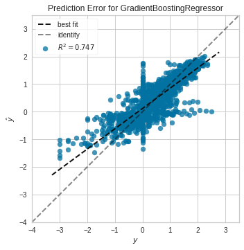

```python
model = GradientBoostingRegressor(random_state=0)
visualizer = PredictionError(model)
visualizer.fit(X_train, y_train)
visualizer.score(X_valid, y_valid)
visualizer.show()
```

### Cook’s Distance

Cook’s Distance is a measure of an observation or instances’ influence on a linear regression. Instances with a large influence may be outliers and datasets that have a large number of highly influential points might not be good predictors to fit linear models. The CooksDistance visualizer shows a stem plot of all instances by index and their associated distance score, along with a heuristic threshold to quickly show what percent of the dataset may be impacting OLS regression models.

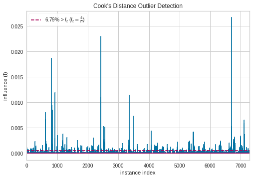

```python
visualizer = CooksDistance()
visualizer.fit(X_train, y_train)
visualizer.show()
```

# Model-Agnostic

### Partial Dependence Plot

Partial dependence plot (PDP) aims to visualize the marginal effect of a given predictor towards the model outcome by plotting out the average model outcome in terms of different values of the predictor.

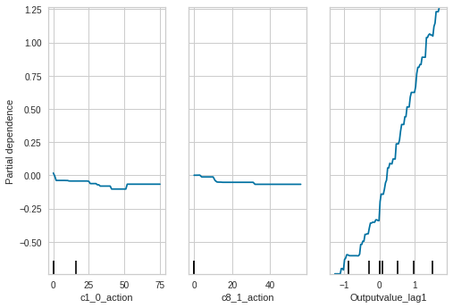

```python
from sklearn.inspection import plot_partial_dependence
reg = GradientBoostingRegressor(random_state=0).fit(X_train, y_train)
disp1 = plot_partial_dependence(reg, X_train,features=[1,2,3])
```

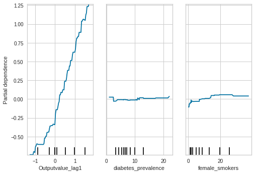

```python
disp1 = plot_partial_dependence(reg, X_train,features=[3,4,5])
```

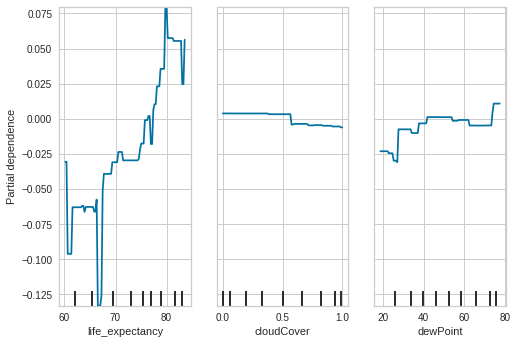

```python
disp1 = plot_partial_dependence(reg, X_train,features=[6,7,8])
```

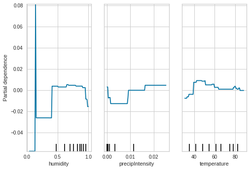

```python
disp1 = plot_partial_dependence(reg, X_train,features=[9,10,11])
```

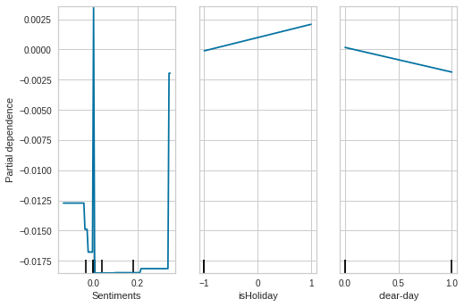

```python
disp1 = plot_partial_dependence(reg, X_train,features=[12,13,14])
```

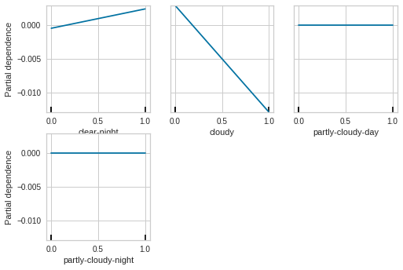

```python
disp1 = plot_partial_dependence(reg, X_train,features=[15,16,17,18])
```